# SIE-02

Sophia Volzke

2025-11-29

Packages

```r
library(terra)
library(tidyverse)
library(sf)
```

# GeoTIFF

## Read data

Monthly Sea Ice Concentrations (25km NSIDC) (SIC) downloaded from Steketee, A., Chua, S., & Commonwealth of Australia. (2023). Nilas Software - mapping tool for displaying multiple layers of physical and biogeochemical variables in the Southern Ocean, Ver. 1. Accessed 22/12/2023 2023. Retrieved from http://dx.doi.org/doi:10.26179/qh66-7p96

Set “path_to_files” as link to file directory.

```r
# Set the path to geotiff files of monthly SIC
path_to_files <- "C:/Users/svolzke/OneDrive - University of Tasmania/RESEARCH - SES Demography/Data/ICE/SIC-25km"
```

## Spatial subset

Check current projection

```r
ext(rast_stack)
```

```
## SpatExtent : -3950000, 3950000, -3950000, 4350000 (xmin, xmax, ymin, ymax)
```

My subset extent is in degrees (longitude and latitude), so I reprojected the raster stack to WGS 84 geographic coordinate system:

```r
# Define your spatial extent
subset_extent <- c(115, 245, -80, -40)

# Set the target CRS - longitudes range from -180 to +180
target_crs <- "+proj=longlat +datum=WGS84"

# Reproject and rotate each raster in the stack individually
rast_stack_rotated <- lapply(rast_stack, function(r) terra::rotate(terra::project(r, target_crs),left=FALSE))

# Combine the list of reprojected and rotated raster layers into a raster stack
rast_stack_rotated <- terra::rast(rast_stack_rotated)

## Subset the rotated and shifted raster stack
rast_subset <- terra::crop(rast_stack_rotated, subset_extent)
```

```r
ext(rast_stack_rotated)
```

```
## SpatExtent : -0.193340494092354, 359.806659505908, -89.8912976566242, -39.2299412121644 (xmin, xmax, ymin, ymax)
```

```r
ext(rast_subset)
```

```
## SpatExtent : 115.037593984962, 244.962406015038, -79.8363719500902, -40.003397035744 (xmin, xmax, ymin, ymax)
```

```r
# Check the structure of rast_subset
str(rast_subset)
```

```
## S4 class 'SpatRaster' [package "terra"]
```

Plot 1) whole circumpolar dataset, a rotated image and the cropped spatial subset:

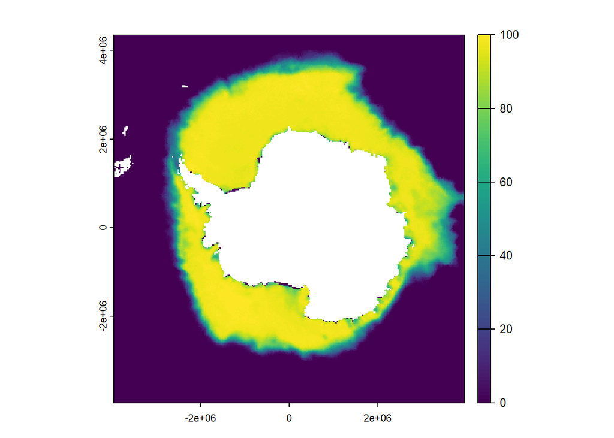

```r
plot(rast_stack[[22]])
```

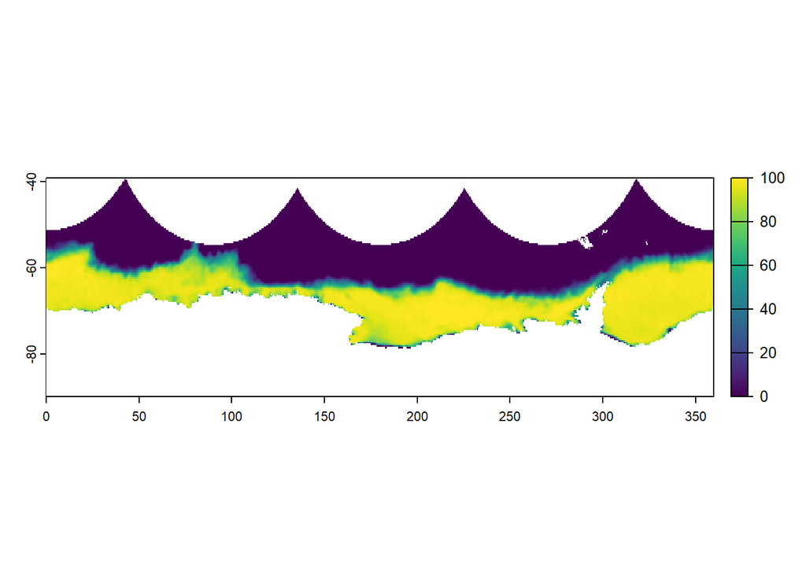

```r
plot(rast_stack_rotated[[22]])
```

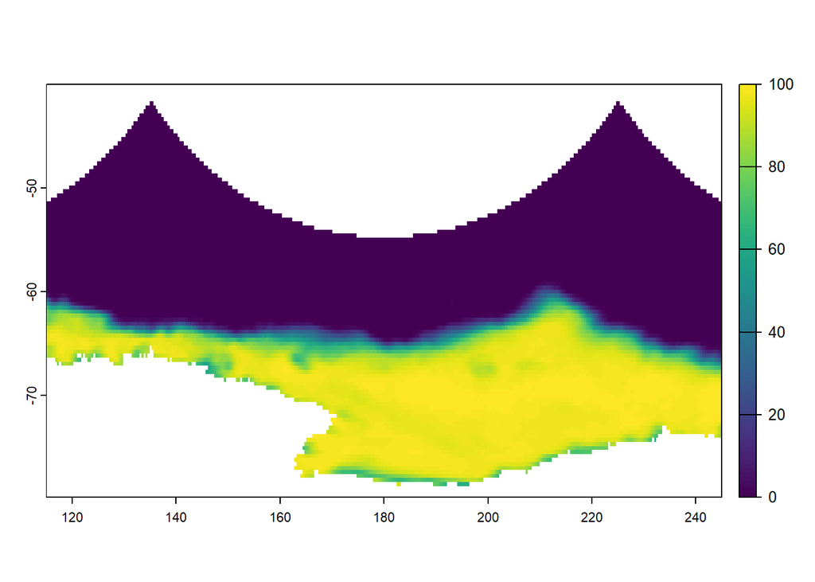

```r
plot(rast_subset[[165]])
```

Then, I read in the a shapefile for the known female southern elephant seal foraging area. File “uds” provided by Mark Hindell and plotted in: Hindell, M. A., McMahon, C. R., Van Den Hoff, J., Thalmann, S., Carlyon, K., & Wotherspoon, S. (2025). The ongoing decrease in numbers of breeding female southern elephant seals (Mirounga leonina L.) at Macquarie Island. Antarctic Science, 1–9. doi:10.1017/S0954102025000161

```r
setwd("C:/Users/svolzke/OneDrive - University of Tasmania/RESEARCH - SES Demography/Data/Hindell-2025-shp")
uds <- read_sf("uds-shapefile.shp")
```

Explore a few plots of “uds”, which has three layers defining area of most use for 25,50 and 75% of time spent in grid cells while foraging. The methodology to calculate individual utilisation distributions (UDi, a measure of the total area used by an individual seal) followed the same methodology as: Harcourt, R., Hindell, M. A., McMahon, C. R., Goetz, K. T., Charrassin, J.-B., Heerah, K., . . . Pinkerton, M. H. (2021). Regional variation in winter foraging strategies by Weddell Seals in eastern Antarctica and the Ross Sea. Frontiers in Marine Science, Volume 8 - 2021. doi:10.3389/fmars.2021.720335

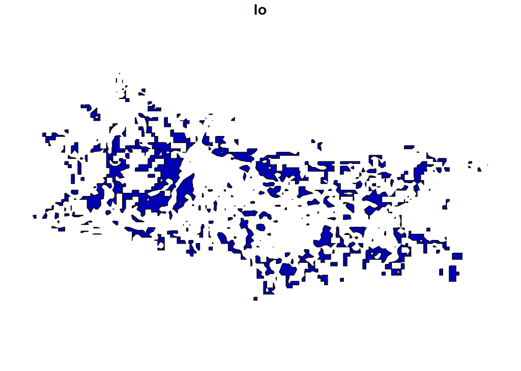

```r
plot(uds[1,1 ])
```

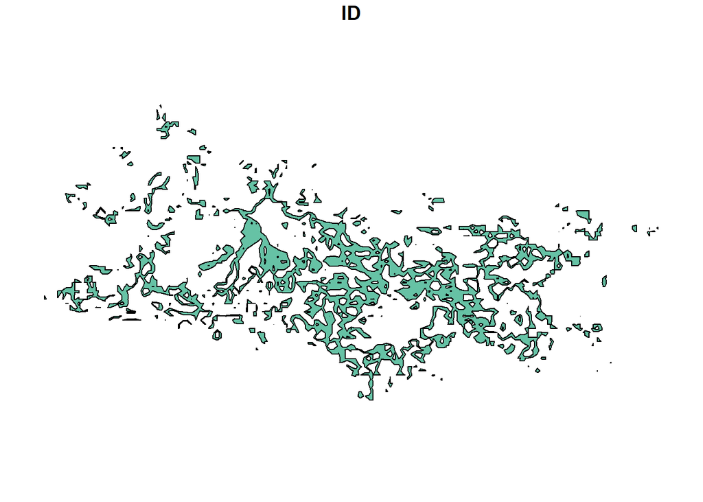

```r
plot(uds[2,3 ])
```

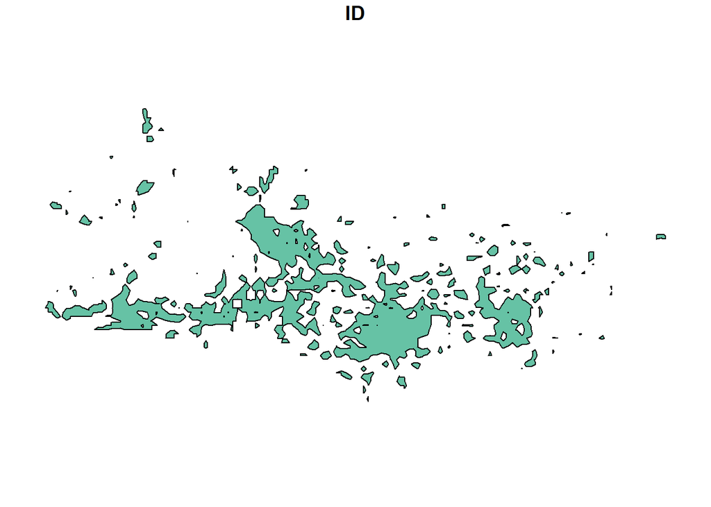

```r
plot(uds[3,3 ])
```

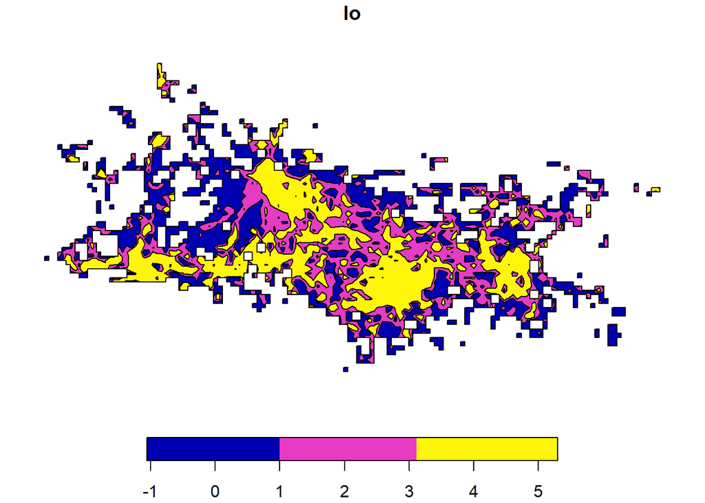

```r
plot(uds[,1 ])
```

```r
uds_50 <- uds[c(2, 3), ]
uds_75 <- uds[c(3), ]
```

The shapes are split to distinguish 50 from 75% spatial extent. However, to use 50% as a full spatial cover of the area, we need to also include the 75% area in our subset. So combining these two into one shapefile:

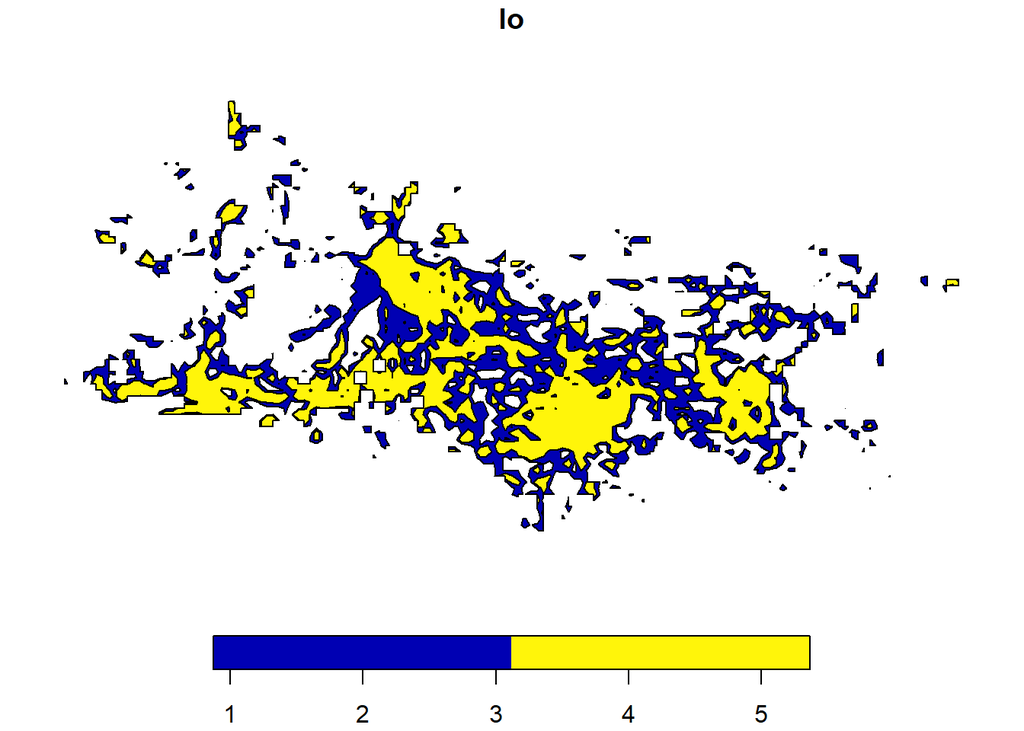

```r
plot(uds_50[,1 ])
```

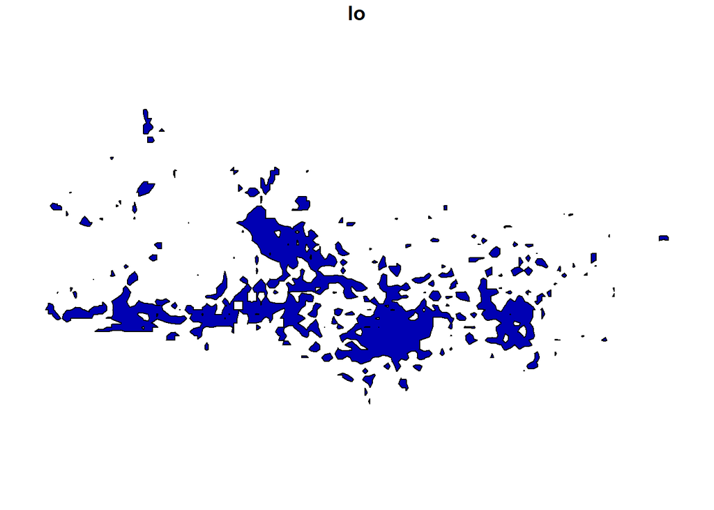

```r
plot(uds_75[,1 ])
```

This is done as per below:

```r
SO_uds_50 <-  crop(rast_subset, vect(uds_50))
SO_uds_50 <- mask(SO_uds_50,vect(uds_50))

SO_uds_75 <-  crop(rast_subset, vect(uds_75))
SO_uds_75 <- mask(SO_uds_75,vect(uds_75))
```

And plotted for the SIC covariate within the cropped spatial extent, for 50 and 75% space use separately:

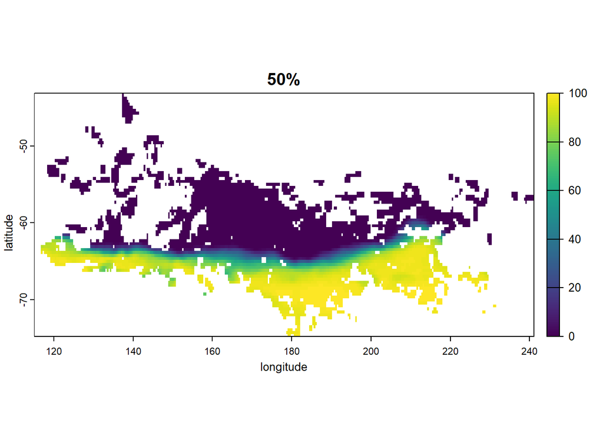

```r
plot(SO_uds_50[[165]], main= "50%", xlab="longitude", ylab="latitude")
```

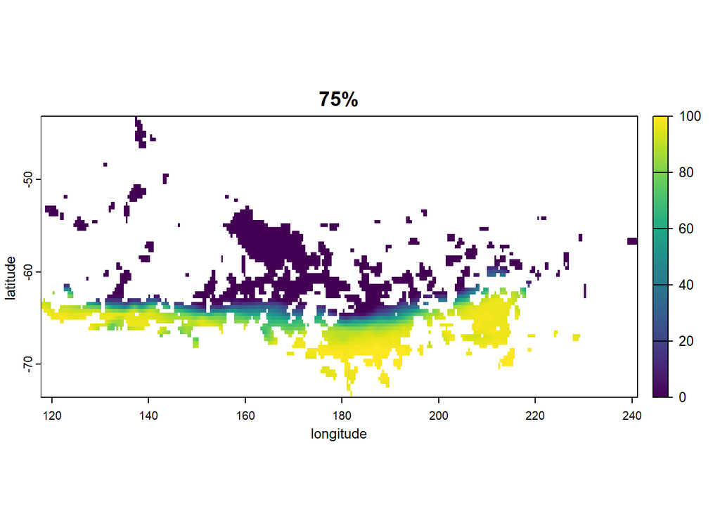

```r
plot(SO_uds_75[[165]], main= "75%", xlab="longitude", ylab="latitude")
```

From here on, we use the 50% subset to generate a covariate for analysis.

```r
ICE_subset <- SO_uds_50
```

Visualise spatial extent of the covariate:

```r
coast=read_sf("antarctic_land.shp")
# Define desired spatial extent
xmin <- 115
xmax <- 245
ymin <- -80
ymax <- -40

# Define the original CRS of the shapefile
original_crs <- st_crs(coast)

# Transform the shapefile to a CRS with a 0-180° longitude range
shapefile_180 <- st_transform(coast, crs = "+proj=longlat +datum=WGS84 +lon_wrap=180")
shapefile_x <- st_transform(coast, crs = "+proj=longlat +datum=WGS84")

#also read in merged uds shape file for outline
poly_sf <- read_sf("uds50_merged.shp")
```

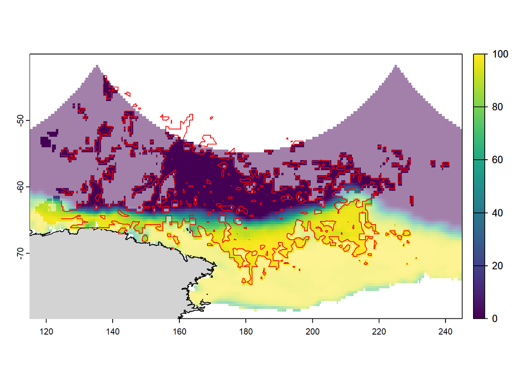

```r
plot(rast_subset[[165]], alpha = 0.5)
plot(shapefile_x, add = TRUE, col = "lightgray", border = "black", lwd = 1)
plot(SO_uds_50[[165]],add=TRUE)
plot(poly_sf , add = TRUE, border = "red", col=NA, lwd = 1)
```